# Covid 19 Data Analysis

Seif Elkateb

2025-03-04

The Covid-19 pandemic in 2020 was unprecedented on the 21th century and there has been millions of global cases and also deaths all over the world. By analyzing the data we then could then learn how to better take actions in the future if another pandemic in the future.

### Goals of the analysis

- Track the progression of the pandemic
- Identify the hot spots and areas that needs better resources
- Evaluate the effectiveness of public heath measures
- Evaluate the effectiveness of the polices set by the government

The data used in this analysis can be accessed from this [COVID-19 Data Repository.](https://github.com/CSSEGISandData/COVID-19/tree/master/csse_covid_19_data/csse_covid_19_time_series)

### Libraries that will be used

- Tidyverse
- Lubridate

```r
#using the tidyverse library
library(tidyverse)
library(lubridate)
```

### Importing the data

```r
#preparing the data and importing them

us_cases<-read_csv("./Data/time_series_covid19_confirmed_US.csv")
global_cases<-read_csv("./Data/time_series_covid19_confirmed_global.csv")
us_deaths<-read_csv("./Data/time_series_covid19_deaths_US.csv")
global_deaths<-read_csv("./Data/time_series_covid19_deaths_global.csv")
look_up<-read_csv("./Data/UID_ISO_FIPS_LookUp_Table.csv")
```

### Tidying and transforing the data

#### **There are 4 csv files**

- **Us Confirmed Cases**
- **Us Death Cases**
- **Global Confirmed Cases**
- **Global Deaths**

### Global Data Tidying

after looking at the global cases and deaths csv files (**global_cases,global_deaths**). I need to do the following.

- The Lat and Long columns are not needed for my analysis on the covid 19 data
- Each date has its own column and that needs to be modified by creating the following columns:
  - Date column where each observation(row) will have one of the dates originally used as columns
  - Cases which will contain the cases on that specific date for the specific country/region
  - Deaths in the case of global_deaths.csv file and it will contain death count for specific country/region
  - The Date on all the csv files is not Date type it’s character type and this needs to be changed to the correct type

```r
# There are 2 csv files related to global cases  : global cases and global deaths

#selecting only the Province/state , country/region , besides creating date and cases in global_cases

global_cases<- global_cases %>% select(-c('Lat','Long'))%>%pivot_longer(cols=-c('Province/State','Country/Region'),names_to="date",values_to ="cases")%>% mutate(date=mdy(date))

#selecting only the Province/state , country/region , besides creating date and deaths in global_deaths

global_deaths<- global_deaths %>% select(-c('Lat','Long'))%>%pivot_longer(cols=-c('Province/State','Country/Region'),names_to="date",values_to ="deaths")%>% mutate(date=mdy(date))
```

now i will create object called global which will contain the data from both the global_deaths and global_cases after tidying them . Also i will rename province/State and Country/region columns for a better readability

```r
global<- global_cases%>% full_join(global_deaths) %>% rename(Country_Region='Country/Region',Province_State='Province/State')
```

### Summary of the data

**There are some observations such as**

- Some dates on the dataset have **0 cases and deaths** and i need to decide whether i want to include them on my analysis or not
- Last Date on the dataset is **2023-03-09**
- Max Number of cases is **103802702**
- Max Number of deaths is **1123836**

```r
summary(global)
```

```
##  Province_State     Country_Region          date                cases
##  Length:330327      Length:330327      Min.   :2020-01-22   Min.   :        0
##  Class :character   Class :character   1st Qu.:2020-11-02   1st Qu.:      680
##  Mode  :character   Mode  :character   Median :2021-08-15   Median :    14429
##                                        Mean   :2021-08-15   Mean   :   959384
##                                        3rd Qu.:2022-05-28   3rd Qu.:   228517
##                                        Max.   :2023-03-09   Max.   :103802702
##      deaths
##  Min.   :      0
##  1st Qu.:      3
##  Median :    150
##  Mean   :  13380
##  3rd Qu.:   3032
##  Max.   :1123836
```

### Decision After analyzing the Global data

- After reviewing the summary of the data i decided i need to filter the observations and only include the ones with cases >0
- now if i do that i will be able to analyze the data better and i will be able how the death column is correlated to the cases column
- some dates have a lot of cases but zero deaths!!

```r
global <- global %>% filter(cases>0)

summary(global)
```

```
##  Province_State     Country_Region          date                cases
##  Length:306827      Length:306827      Min.   :2020-01-22   Min.   :        1
##  Class :character   Class :character   1st Qu.:2020-12-12   1st Qu.:     1316
##  Mode  :character   Mode  :character   Median :2021-09-16   Median :    20365
##                                        Mean   :2021-09-11   Mean   :  1032863
##                                        3rd Qu.:2022-06-15   3rd Qu.:   271281
##                                        Max.   :2023-03-09   Max.   :103802702
##      deaths
##  Min.   :      0
##  1st Qu.:      7
##  Median :    214
##  Mean   :  14405
##  3rd Qu.:   3665
##  Max.   :1123836
```

### US Data Tidying

- no need for lat, long columns
- dates have columns and need to be transformed into a column called date and corresponding deaths or cases
- dates need to be transformed to date obj
- province_state and country_region don’t need to be renamed
- UID, ISO2 , ISO3 , CODE 3 ,Fips
- Admin 2 , combined key ,population need to be present
- The US_deaths have population column while US_cases don’t have that column

```r
# There are 2 csv files related to US   : global cases and global deaths

#selecting only the Province/state , country/region , besides creating date and cases in global_cases

us_cases<- us_cases %>% select(-c('UID','Lat','Long_','iso2','iso3','code3','FIPS'))%>%pivot_longer(cols=-c('Province_State','Country_Region','Admin2','Combined_Key'),names_to="date",values_to ="cases")%>% mutate(date=mdy(date))



us_deaths<- us_deaths %>% select(-c('UID','Lat','Long_','iso2','iso3','code3','FIPS'))%>%pivot_longer(cols=-c('Province_State','Country_Region','Admin2','Combined_Key','Population'),names_to="date",values_to ="deaths")%>% mutate(date=mdy(date))
```

### Us Data

```r
us<-us_cases %>%full_join(us_deaths)

summary(us)
```

```
##     Admin2          Province_State     Country_Region     Combined_Key
##  Length:3819906     Length:3819906     Length:3819906     Length:3819906
##  Class :character   Class :character   Class :character   Class :character
##  Mode  :character   Mode  :character   Mode  :character   Mode  :character
##
##
##
##       date                cases           Population           deaths
##  Min.   :2020-01-22   Min.   :  -3073   Min.   :       0   Min.   :  -82.0
##  1st Qu.:2020-11-02   1st Qu.:    330   1st Qu.:    9917   1st Qu.:    4.0
##  Median :2021-08-15   Median :   2272   Median :   24892   Median :   37.0
##  Mean   :2021-08-15   Mean   :  14088   Mean   :   99604   Mean   :  186.9
##  3rd Qu.:2022-05-28   3rd Qu.:   8159   3rd Qu.:   64979   3rd Qu.:  122.0
##  Max.   :2023-03-09   Max.   :3710586   Max.   :10039107   Max.   :35545.0
```

### summary US data

```r
#us dataset sumamry after filtering
summary(us)
```

```
##     Admin2          Province_State     Country_Region     Combined_Key
##  Length:3819906     Length:3819906     Length:3819906     Length:3819906
##  Class :character   Class :character   Class :character   Class :character
##  Mode  :character   Mode  :character   Mode  :character   Mode  :character
##
##
##
##       date                cases           Population           deaths
##  Min.   :2020-01-22   Min.   :  -3073   Min.   :       0   Min.   :  -82.0
##  1st Qu.:2020-11-02   1st Qu.:    330   1st Qu.:    9917   1st Qu.:    4.0
##  Median :2021-08-15   Median :   2272   Median :   24892   Median :   37.0
##  Mean   :2021-08-15   Mean   :  14088   Mean   :   99604   Mean   :  186.9
##  3rd Qu.:2022-05-28   3rd Qu.:   8159   3rd Qu.:   64979   3rd Qu.:  122.0
##  Max.   :2023-03-09   Max.   :3710586   Max.   :10039107   Max.   :35545.0
```

### Final Transformation of the data

- Global data does not have the population column
- Global data does not have the combined key and i would either have to add it to the global data or remove it

```r
global<- global %>% unite('Combined_Key',c(Province_State,Country_Region),sep=", ",na.rm=TRUE,remove=FALSE)



look_up<-look_up%>%select(-c(Lat, Long_, Combined_Key, code3, iso2, iso3, Admin2))

global<- global %>% left_join(look_up,by=c('Province_State','Country_Region'))%>% select(-c('UID','FIPS'))
summary(global)
```

```
##  Combined_Key       Province_State     Country_Region          date
##  Length:306827      Length:306827      Length:306827      Min.   :2020-01-22
##  Class :character   Class :character   Class :character   1st Qu.:2020-12-12
##  Mode  :character   Mode  :character   Mode  :character   Median :2021-09-16
##                                                           Mean   :2021-09-11
##                                                           3rd Qu.:2022-06-15
##                                                           Max.   :2023-03-09
##
##      cases               deaths          Population
##  Min.   :        1   Min.   :      0   Min.   :6.700e+01
##  1st Qu.:     1316   1st Qu.:      7   1st Qu.:7.866e+05
##  Median :    20365   Median :    214   Median :6.948e+06
##  Mean   :  1032863   Mean   :  14405   Mean   :2.890e+07
##  3rd Qu.:   271281   3rd Qu.:   3665   3rd Qu.:2.914e+07
##  Max.   :103802702   Max.   :1123836   Max.   :1.380e+09
##                                        NA's   :6729
```

### Data Visualization

- Now moving for the data visualization but before that we need to do more transformation to the data frame and maybe create new data frames that we can do visualizations on them

```r
# the sum of the population in US
# this is the sum of the population of the US




US_by_state <- us %>%
group_by(Province_State, Country_Region, date) %>%
summarize(cases = sum(cases), deaths = sum(deaths),
Population = sum(Population)) %>%
mutate(deaths_per_mill = deaths *1000000 / Population) %>%
select(Province_State, Country_Region, date,
cases, deaths, deaths_per_mill, Population) %>%
ungroup()



US_totals <- us %>%
group_by(Country_Region, date) %>%
summarize(cases = sum(cases), deaths = sum(deaths),
Population = sum(Population)) %>%
mutate(deaths_per_mill = deaths *1000000 / Population) %>%
select(Country_Region, date,
cases, deaths, deaths_per_mill, Population) %>%
ungroup()



tail(US_totals)
```

```
## # A tibble: 6 × 6
##   Country_Region date           cases  deaths deaths_per_mill Population
##   <chr>          <date>         <dbl>   <dbl>           <dbl>      <dbl>
## 1 US             2023-03-04 103650837 1122172           3371.  332875137
## 2 US             2023-03-05 103646975 1122134           3371.  332875137
## 3 US             2023-03-06 103655539 1122181           3371.  332875137
## 4 US             2023-03-07 103690910 1122516           3372.  332875137
## 5 US             2023-03-08 103755771 1123246           3374.  332875137
## 6 US             2023-03-09 103802702 1123836           3376.  332875137
```

### Data Visualization

**Cases Versus Deaths in US all country**

```
## [1] "2023-03-09"
```

```
## [1] 1123836
```

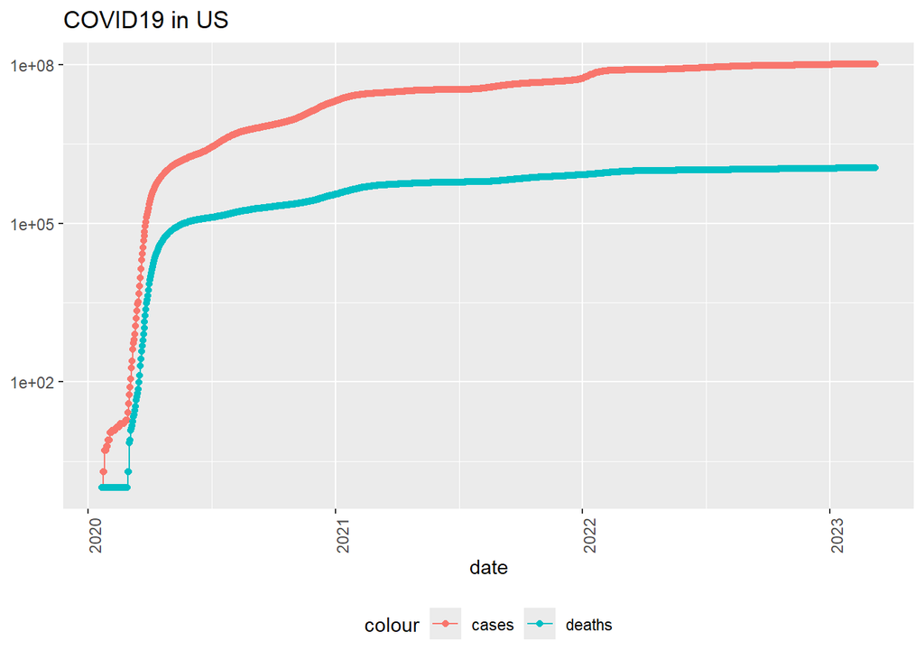

Cases Versus Deaths in specific States

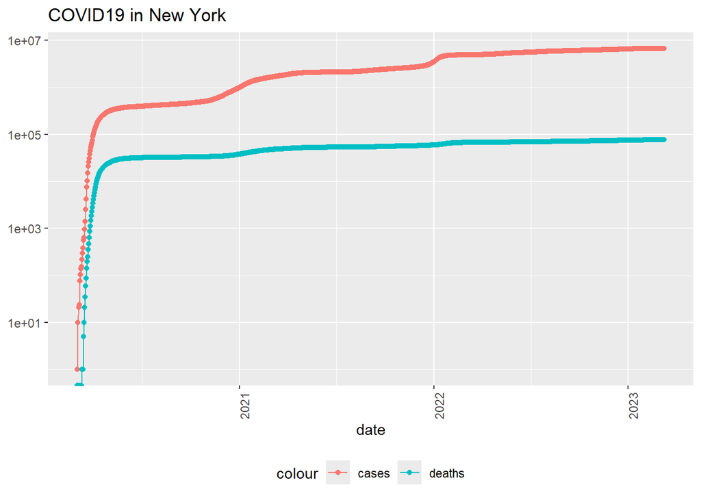

```r
state <- "New York"
US_by_state %>%
filter(Province_State == state) %>%
filter(cases > 0) %>%
ggplot(aes(x = date, y = cases)) +
geom_line(aes(color = "cases")) +
geom_point(aes(color = "cases")) +
geom_line(aes(y = deaths, color = "deaths")) +
geom_point(aes(y = deaths, color = "deaths")) +
scale_y_log10() +
theme(legend.position="bottom",
axis.text.x = element_text(angle = 90)) +
labs(title = str_c("COVID19 in ", state), y= NULL)
```

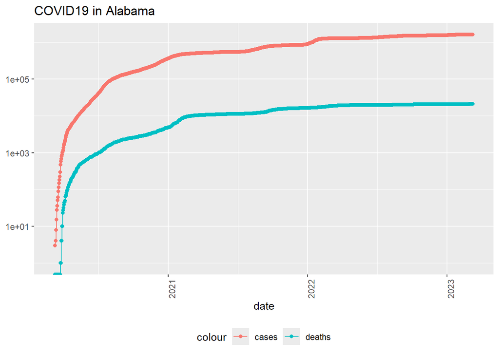

```r
## covid 19 in Alabama

state <- "Alabama"
US_by_state %>%
filter(Province_State == state) %>%
filter(cases > 0) %>%
ggplot(aes(x = date, y = cases)) +
geom_line(aes(color = "cases")) +
geom_point(aes(color = "cases")) +
geom_line(aes(y = deaths, color = "deaths")) +
geom_point(aes(y = deaths, color = "deaths")) +
scale_y_log10() +
theme(legend.position="bottom",
axis.text.x = element_text(angle = 90)) +
labs(title = str_c("COVID19 in ", state), y= NULL)
```

[figure not shown]

```r
# Summarize daily deaths globally
global_daily_deaths <- global_deaths %>%
  group_by(date) %>%
  summarize(daily_deaths = sum(deaths)) %>%
  ungroup()

# Create line plot
ggplot(global_daily_deaths, aes(x = date, y = daily_deaths)) +
  geom_line(color = "red") +
  theme_minimal() +
  labs(title = "Daily COVID-19 Deaths Globally", x = "Date", y = "Daily Deaths")
```

### Summarize total cases by country and select top 10

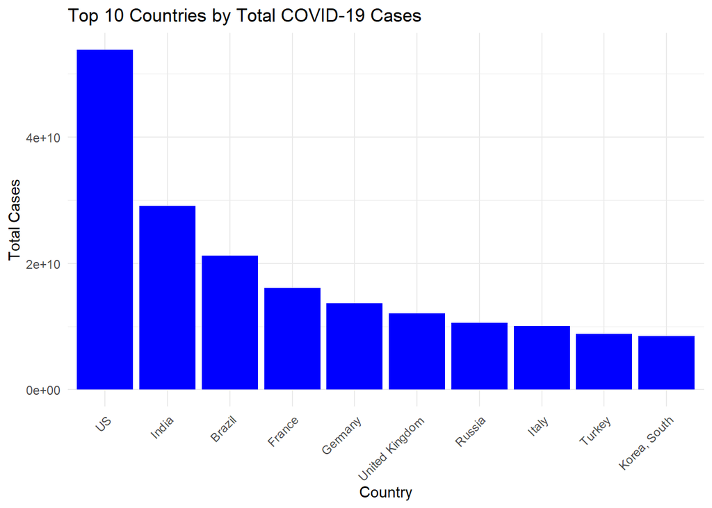

```r
# Summarize total cases by country and select top 10
global_cases_by_country <- global_cases %>%
  group_by(`Country/Region`) %>%
  summarize(total_cases = sum(cases)) %>%
  ungroup() %>%
  top_n(10, total_cases)

# Create bar plot
ggplot(global_cases_by_country, aes(x = reorder(`Country/Region`, -total_cases), y = total_cases)) +
  geom_bar(stat = "identity", fill = "blue") +
  theme_minimal() +
  labs(title = "Top 10 Countries by Total COVID-19 Cases", x = "Country", y = "Total Cases") +
  theme(axis.text.x = element_text(angle = 45, hjust = 1))
```

### Modeling Data

```r
US_state_totals <- US_by_state %>%
group_by(Province_State) %>%
summarize(deaths = max(deaths), cases = max(cases),
population = max(Population),
cases_per_thou = 1000* cases / population,
deaths_per_thou = 1000 * deaths / population) %>%
filter(cases > 200000, population > 0)


mod <-lm(deaths_per_thou ~ cases_per_thou, data = US_state_totals)


summary(mod)
```

```
##
## Call:
## lm(formula = deaths_per_thou ~ cases_per_thou, data = US_state_totals)
##
## Residuals:
##     Min      1Q  Median      3Q     Max
## -2.0703 -0.5694  0.1442  0.5590  1.1294
##
## Coefficients:
##                Estimate Std. Error t value Pr(>|t|)
## (Intercept)    0.979691   0.861616   1.137  0.26129
## cases_per_thou 0.007457   0.002708   2.754  0.00834 **
## ---
## Signif. codes:  0 '***' 0.001 '**' 0.01 '*' 0.05 '.' 0.1 ' ' 1
##
## Residual standard error: 0.8089 on 47 degrees of freedom
## Multiple R-squared:  0.139,  Adjusted R-squared:  0.1206
## F-statistic: 7.585 on 1 and 47 DF,  p-value: 0.008342
```

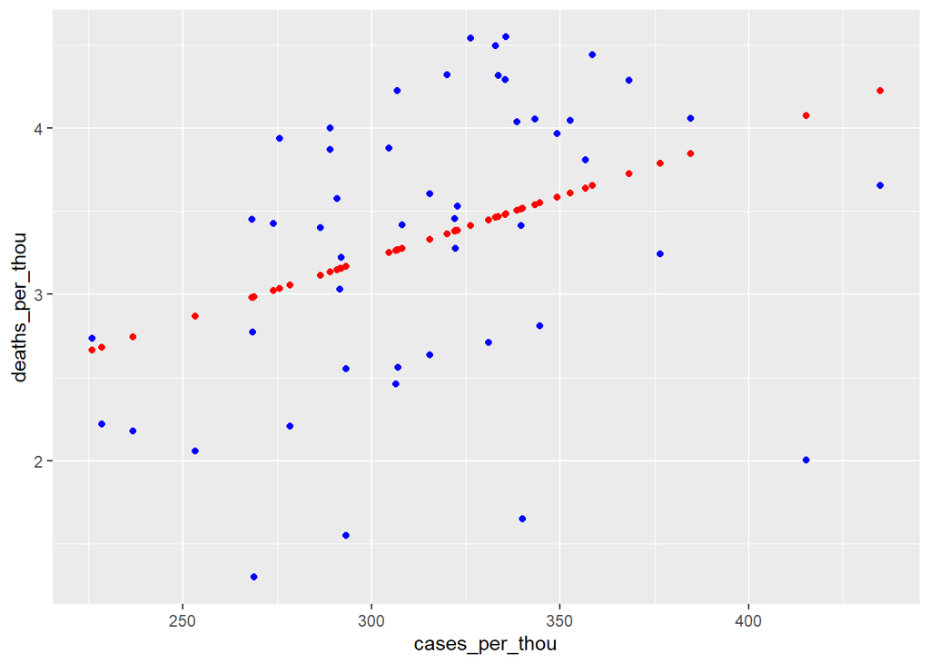

```r
US_tot_w_pred <- US_state_totals %>% mutate(pred = predict(mod))



US_tot_w_pred %>% ggplot() + geom_point(aes(x = cases_per_thou, y = deaths_per_thou), color = "blue") + geom_point(aes(x = cases_per_thou, y = pred), color = "red")
```